# Analysis on Globel Marriage Rate

## Overview

Marriage was once said to be the path to happiness. But I notice that nowadays not all people want to get married. Many of my friends from China expressed to me their ideas about not getting married, I wonder if this is just the opinion from people around me or it is a common phenomenon around the globe. Furthermore, what is the cause of the decrease in marriage rate?

This tutorial introduces an analysis on marriage rate globally from 1960 to 2017. It will include the following parts:

- Data collecting and managing
- Exploratory data analysis
- Regression and Hypothesis Testing

## Data Source

- marriage rate: [OECD Family Database](http://www.oecd.org/els/family/database.htm).
- GDP per capita: [The World Bank](https://data.worldbank.org/indicator/NY.GDP.PCAP.CD).
- education score: [World Population Review](https://worldpopulationreview.com/countries/education-rankings-by-country/).
- income per person: [Kaggle](https://www.kaggle.com/psterk/income-inequality?select=income_per_person_gdppercapita_ppp_inflation_adjusted.csv).

## Required Tools

Below are libraries that we are using for this tutorial

- Pandas
- Numpy
- Matplotlib
- Seaborn
- Scikit-learn
- Statsmodels

```python
# import necessary modules
import pandas as pd
import numpy as np
import matplotlib.pyplot as plt
import seaborn as sns
from sklearn.linear_model import LinearRegression
from statsmodels.formula.api import ols
import statsmodels.api as sm

sns.set()
```

Before we start, we want to load our data in csv files into pandas dataframe.

```python
# creat pandas DataFrames
marriage = pd.read_csv("Marriage_rates.csv", sep=',')
gdp = pd.read_csv("GDP_per_capita.csv", sep=',')
education = pd.read_csv("education.csv", sep=',')
income = pd.read_csv("income_per_person_gdppercapita_ppp_inflation_adjusted.csv", sep=',')
```

## Data management

Now that we have have our dataframes, we want to tidy the data to help make our future analysis more convenient. To do that, we will need to:

- figure out a way to deal with the missing data
- reorganize our dataframe to help with our data visualizations later

To get rid of missing data, we will use [pandas.DataFrame.interpolate](https://pandas.pydata.org/pandas-docs/stable/reference/api/pandas.DataFrame.interpolate.html). By choosing the 'nearest' method we set the missing values to the nearest value.

```python
# identify the missing data and set them to NaN
marriage=marriage.replace('..','NaN')
country=marriage.iloc[:,:1]
# fill the missing values using the nearest values
marriage=marriage.iloc[:,1:].astype(float).interpolate(method='nearest', axis=0).ffill().bfill()
new_marriage=country.join(marriage)
new_marriage.head()
```

|  | Country | 1960 | 1961 | 1962 | 1963 | 1964 | 1965 | 1966 | 1967 | 1968 | ... | 2008 | 2009 | 2010 | 2011 | 2012 | 2013 | 2014 | 2015 | 2016 | 2017 |
| --- | --- | --- | --- | --- | --- | --- | --- | --- | --- | --- | --- | --- | --- | --- | --- | --- | --- | --- | --- | --- | --- |
| 0 | Australia | 8.3 | 8.5 | 8.4 | 8.1 | 8.0 | 7.8 | 7.6 | 7.6 | 7.6 | ... | 5.5 | 5.5 | 5.4 | 5.4 | 5.4 | 5.1 | 5.2 | 4.8 | 4.9 | 4.6 |
| 1 | Austria | 8.3 | 8.5 | 8.4 | 8.1 | 8.0 | 7.8 | 7.6 | 7.6 | 7.6 | ... | 4.2 | 4.3 | 4.5 | 4.3 | 4.6 | 4.3 | 4.4 | 5.1 | 5.1 | 5.1 |
| 2 | Belgium | 7.1 | 6.8 | 6.7 | 6.7 | 6.9 | 7.0 | 7.2 | 7.1 | 7.2 | ... | 4.3 | 4.0 | 3.9 | 3.7 | 3.8 | 3.4 | 3.6 | 4.0 | 3.9 | 3.9 |
| 3 | Canada | 7.3 | 7.0 | 7.0 | 6.9 | 7.2 | 7.4 | 7.8 | 8.1 | 8.3 | ... | 4.4 | 4.0 | 3.9 | 3.7 | 3.8 | 3.4 | 3.6 | 4.0 | 3.9 | 3.9 |
| 4 | Chile | 7.3 | 7.0 | 7.0 | 6.9 | 7.2 | 7.4 | 7.8 | 8.1 | 8.3 | ... | 3.3 | 3.3 | 3.5 | 3.8 | 3.7 | 3.5 | 3.6 | 3.4 | 3.4 | 5.0 |

5 rows × 59 columns

```python
gdp=gdp.replace('..','NaN')
country=gdp.iloc[:,:1]
gdp=gdp.iloc[:,1:].astype(float).interpolate(method='nearest', axis=0).ffill().bfill()
new_gdp=country.join(gdp)
new_gdp.head()
```

|  | Country Name | 1960 | 1961 | 1962 | 1963 | 1964 | 1965 | 1966 | 1967 | 1968 | ... | 2009 | 2010 | 2011 | 2012 | 2013 | 2014 | 2015 | 2016 | 2017 | 2018 |
| --- | --- | --- | --- | --- | --- | --- | --- | --- | --- | --- | --- | --- | --- | --- | --- | --- | --- | --- | --- | --- | --- |
| 0 | Aruba | 59.773194 | 59.860874 | 58.458015 | 78.706388 | 82.095231 | 101.108305 | 137.594352 | 160.898589 | 129.108323 | ... | 24630.453710 | 23512.602600 | 24985.993280 | 24713.698050 | 25025.099560 | 25533.569780 | 25796.380250 | 25239.600410 | 25630.266490 | 520.896603 |
| 1 | Afghanistan | 59.773194 | 59.860874 | 58.458015 | 78.706388 | 82.095231 | 101.108305 | 137.594352 | 160.898589 | 129.108323 | ... | 438.076034 | 543.303042 | 591.162347 | 641.872034 | 637.165044 | 613.856333 | 578.466353 | 547.228110 | 556.302138 | 520.896603 |
| 2 | Angola | 59.773194 | 59.860874 | 58.458015 | 78.706388 | 82.095231 | 101.108305 | 137.594352 | 160.898589 | 129.108323 | ... | 3122.780766 | 3587.883798 | 4615.468028 | 5100.095808 | 5254.882338 | 5408.410496 | 4166.979684 | 3506.072885 | 4095.812942 | 3432.385736 |
| 3 | Albania | 59.773194 | 59.860874 | 58.458015 | 78.706388 | 82.095231 | 101.108305 | 137.594352 | 160.898589 | 129.108323 | ... | 4114.140150 | 4094.362119 | 4437.178067 | 4247.614279 | 4413.081743 | 4578.666720 | 3952.829458 | 4124.108907 | 4532.890162 | 5268.848504 |
| 4 | Andorra | 59.773194 | 59.860874 | 58.458015 | 78.706388 | 82.095231 | 101.108305 | 137.594352 | 160.898589 | 223.938948 | ... | 43338.866760 | 39736.354060 | 41100.729940 | 38392.943900 | 40626.751630 | 42300.334130 | 36039.653500 | 37224.108920 | 39134.393370 | 42029.762740 |

5 rows × 60 columns

Setting each year as a column is not convenient for us to visualize the data across time, so we want to reconstruct the dataframe. We will use [pandas.melt](https://pandas.pydata.org/docs/reference/api/pandas.melt.html) to construct the dataframe by 'Country' and 'Date'.

```python
marriage_data=new_marriage.melt(id_vars=["Country"], var_name="Date")
marriage_data = marriage_data.rename(columns={'value': 'marriage_rate'})
marriage_data.head()
```

|  | Country | Date | marriage_rate |
| --- | --- | --- | --- |
| 0 | Australia | 1960 | 8.3 |
| 1 | Austria | 1960 | 8.3 |
| 2 | Belgium | 1960 | 7.1 |
| 3 | Canada | 1960 | 7.3 |
| 4 | Chile | 1960 | 7.3 |

```python
gdp_data=new_gdp.melt(id_vars=["Country Name"], var_name="Date")
gdp_data = gdp_data.rename(columns={'value': 'gdp_rate','Country Name': 'Country'})
gdp_data.head()
```

|  | Country | Date | gdp_rate |
| --- | --- | --- | --- |
| 0 | Aruba | 1960 | 59.773194 |
| 1 | Afghanistan | 1960 | 59.773194 |
| 2 | Angola | 1960 | 59.773194 |
| 3 | Albania | 1960 | 59.773194 |
| 4 | Andorra | 1960 | 59.773194 |

```python
education=education.iloc[:,:2]
education = education.rename(columns={'name': 'Country','totalScore': 'education'})
education.head()
```

|  | Country | education |
| --- | --- | --- |
| 0 | China | 1731 |
| 1 | Hong Kong | 1637 |
| 2 | Finland | 1631 |
| 3 | Singapore | 1630 |
| 4 | Japan | 1588 |

```python
income=income.melt(id_vars=["country"], var_name="Date")
income = income.rename(columns={'value': 'income','country':'Country'})
income['Date']=income['Date'].astype(int)
income.head()
```

|  | Country | Date | income |
| --- | --- | --- | --- |
| 0 | Afghanistan | 1800 | 603 |
| 1 | Albania | 1800 | 667 |
| 2 | Algeria | 1800 | 715 |
| 3 | Andorra | 1800 | 1200 |
| 4 | Angola | 1800 | 618 |

Finally, we combine those dataframes into one. We are using the 'inner' so that we don't create more missing values

```python
# merge dataframes into one.
data=pd.merge(marriage_data,gdp_data,how='inner',on=['Country','Date'])
data=pd.merge(data,education,how='inner',on=['Country'])
data['Date']=data['Date'].astype(int)
data=pd.merge(data,income,how='inner',on=['Country','Date'])

data.head()
```

|  | Country | Date | marriage_rate | gdp_rate | education | income |
| --- | --- | --- | --- | --- | --- | --- |
| 0 | Australia | 1960 | 8.3 | 1807.785710 | 1556 | 14300 |
| 1 | Australia | 1961 | 8.5 | 1874.732106 | 1556 | 14100 |
| 2 | Australia | 1962 | 8.4 | 1851.841851 | 1556 | 14700 |
| 3 | Australia | 1963 | 8.1 | 1964.150470 | 1556 | 15400 |
| 4 | Australia | 1964 | 8.0 | 2128.068355 | 1556 | 16100 |

### EDA

Exploratory data analysis is an approach to analyze data sets and to summarize their main characteristics. In this section, we will try to draw graphs to visualize our data, and discuss what we can learn from it.

To begin with, I want to know about the marriage rate in China.

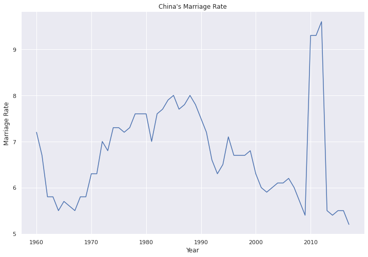

```python
# Get the row for china's marriage rate
china=data.loc[data['Country'] == 'China']

# Plot
plt.figure(figsize=(12,8))
plt.plot(china['Date'],china['marriage_rate'])
plt.xlabel("Year")
plt.ylabel("Marriage Rate")
plt.title("China's Marriage Rate")
plt.show()
```

Now, let's compare between different countries. The graph below shows how much has the marriage rate decreased between 1960 and 2017 for each country.

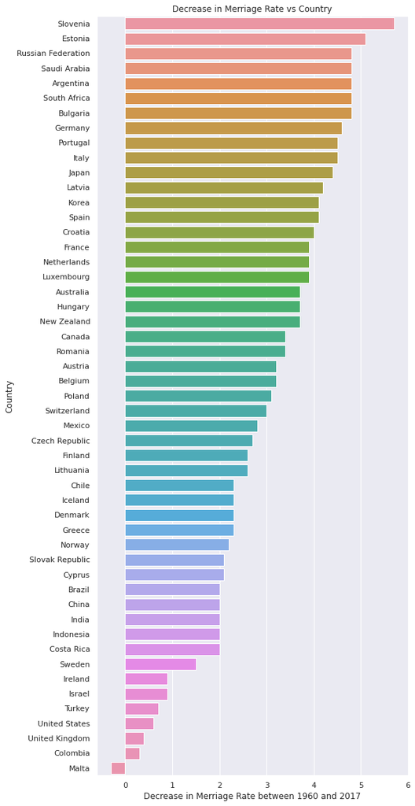

```python
# get difference of marriage rate for each country
m=pd.DataFrame(data=new_marriage['Country'])
m['diff']=new_marriage['1960']-new_marriage['2017']
# sort by decending
m=m.sort_values(by='diff',ascending=False)

# Plot the barplot
plt.figure(figsize=(8,20))
sns.barplot(x=m['diff'],y=m['Country'])
plt.xlabel("Decrease in Merriage Rate between 1960 and 2017")
plt.ylabel("Country")
plt.title("Decrease in Merriage Rate vs Country")
plt.show()
```

We observe that nearly all countries' marriage rate has decreased compared to in 1960. Slovenia's marriage rate has decreased the most.

This bar plot only shows the decreased rate between 1960 and 2017. If we want to further know the distribution of marriage rate for each country, it is good to use the violin plot. The violin plot shows not only the distribution of the data, but also the probability density of the data at different values.

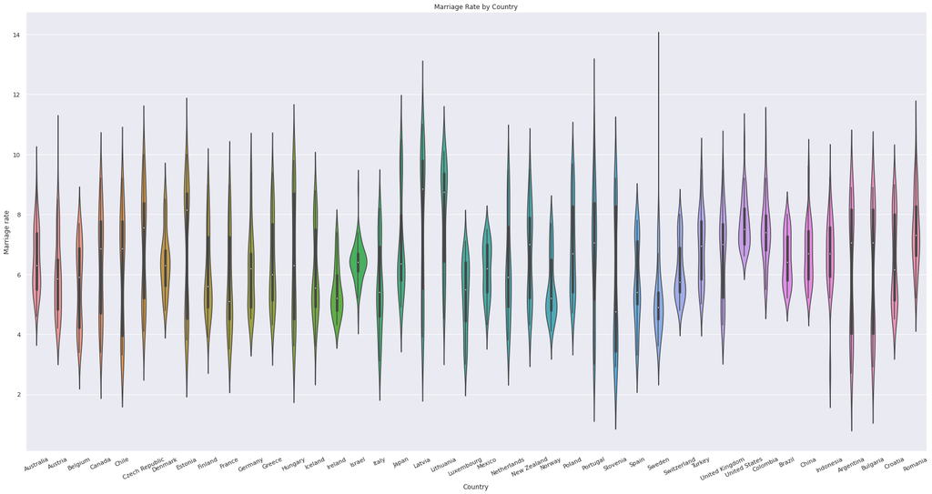

```python
plt.figure(figsize=(30,15))
sns.violinplot(x=data['Country'],y=data['marriage_rate'])
# label the plot
plt.xticks(rotation=25)
plt.xlabel("Country")
plt.ylabel("Marriage rate")
plt.title("Marriage Rate by Country")
plt.show()
```

From the graph, we can see that the distribution of data are significantly different for each country. Some of the countries undergoes big change in marriage rate over the years while some has a quite stable marriage rate.

Our next question is, how does the marriage rate look across time?

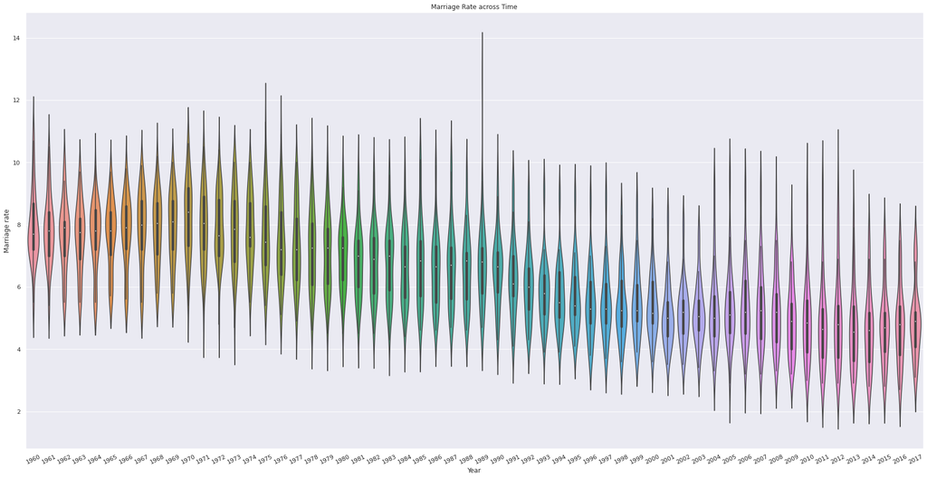

```python
plt.figure(figsize=(30,15))
sns.violinplot(x=data['Date'],y=data['marriage_rate'])
# label the plot
plt.xticks(rotation=25)
plt.xlabel("Year")
plt.ylabel("Marriage rate")
plt.title("Marriage Rate across Time")
plt.show()
```

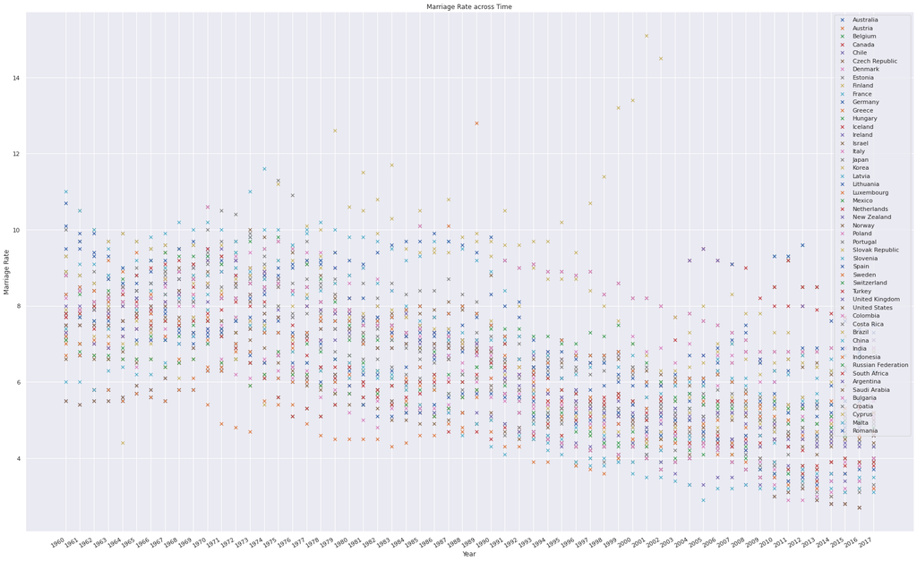

```python
year = list(new_marriage.columns.values)[1:]

fig, ax = plt.subplots(figsize=(30,20))
fig.autofmt_xdate()
for row in new_marriage.iterrows():
    ax.scatter(x=year, y=row[1][1:].astype(float), marker='x',label=row[1][0])
    ax.legend()

ax.set(xlabel="Year", ylabel="Marriage Rate", title="Marriage Rate across Time")
plt.show()
```

Both the violin plot and the scatter plot shows that the marriage rate is decreasing over the years

## Regression and Hypothesis Testing

To further examine the relationship between time and marriage rate, we try to construct a linear regression model and use hypothesis testing to verify if our model fit the data well.

Our first step is to find out whether there exist a linear relationship between time and marriage rate. We already see this decreasing tread in the violin plot and scatter plot above, now we will be using [Pearson correlation coefficient](https://en.wikipedia.org/wiki/Pearson_correlation_coefficient) to see how strong is this linear relationship. Pearson correlation coefficient measures the linear correlation between two sets of data. It has a value between −1 and 1. The greater the absolute value indicates the stronger the linear relationship. A positive correlation coefficient means there exist a positive linear relationship while a negative correlation coefficient means there exist a negative linear relationship.

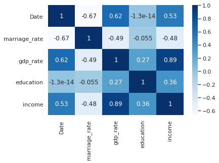

```python
sns.heatmap(data.corr(), annot=True, cmap='Blues')
plt.show()
```

The correlation coefficient of marriage rate and gdp rate/income is about -0.5, this indecates a negative linear relationship. However, it is not high enough for us to construct a good regression model. Here we see that the correlation coefficient of marriage rate and Date is -0.67, which shows a relatively strong negative linear relationship. Therefore, we continue our next step to construct our regression model.

There are many ways to construct a regression model.

[scipy.stats.linregress](https://docs.scipy.org/doc/scipy-0.14.0/reference/generated/scipy.stats.linregress.html) handles the case of a single explanatory variable with specialized code and calculates a few extra statistics;

[numpy.polynomial.polynomial.polyfit](https://numpy.org/doc/stable/reference/generated/numpy.polynomial.polynomial.polyfit.html) estimates the regression for a polynomial of a single variable, it doesn't return much in terms of extra statisics.

[statsmodels.formula.api.ols](https://www.statsmodels.org/stable/generated/statsmodels.formula.api.ols.html#generated-statsmodels-formula-api-ols--page-root) returns the estimated parameters and a set of results staistics and methods for statistical inference and prediction.

We want to see the results staistics and methods for statistical inference and prediction so we will be using statsmodels.formula.api.ols.

```python
regression1 = ols(formula="marriage_rate ~ Date", data=data).fit()
regression1.summary()
```

OLS Regression Results

| Dep. Variable: | marriage_rate | R-squared: | 0.445 |
| --- | --- | --- | --- |
| Model: | OLS | Adj. R-squared: | 0.445 |
| Method: | Least Squares | F-statistic: | 1952. |
| Date: | Mon, 17 May 2021 | Prob (F-statistic): | 1.31e-313 |
| Time: | 19:01:27 | Log-Likelihood: | -3957.2 |
| No. Observations: | 2436 | AIC: | 7918. |
| Df Residuals: | 2434 | BIC: | 7930. |
| Df Model: | 1 |  |  |
| Covariance Type: | nonrobust |  |  |

|  | coef | std err | t | P>\|t\| | [0.025 | 0.975] |
| --- | --- | --- | --- | --- | --- | --- |
| Intercept | 137.0450 | 2.957 | 46.344 | 0.000 | 131.246 | 142.844 |
| Date | -0.0657 | 0.001 | -44.183 | 0.000 | -0.069 | -0.063 |

| Omnibus: | 152.631 | Durbin-Watson: | 0.248 |
| --- | --- | --- | --- |
| Prob(Omnibus): | 0.000 | Jarque-Bera (JB): | 186.895 |
| Skew: | 0.609 | Prob(JB): | 2.61e-41 |
| Kurtosis: | 3.599 | Cond. No. | 2.36e+05 |

Notes:  
[1] Standard Errors assume that the covariance matrix of the errors is correctly specified.  
[2] The condition number is large, 2.36e+05. This might indicate that there are  
strong multicollinearity or other numerical problems.

Independent Var: Date

Dependent Var: marriage_rate

R-squared value = 0.445

P>|t| = 0.00

The P>|t| is the p-value for our hypothesis testing reguarding the coefficient for the intercept and independent variable.

Null Hypothesis: The value of the coefficient is not significantly different from 0.

Alternative Hypothesis: The value of the coefficient is significantly different from 0.

Since P>|t| < 0.05 (significance level), we reject the null hypothesis and conclude that the coefficient value we get is significantly different from zero.

The R-squared value means 44.5% of the observed variation for marriage can be explained by Date. 44.5% is not very high, therefore we need to find a way to improve our regression model.

Recall our violin plot in the above section, the marriage rate also differs between different country. Let's take that into account and reconstruct our model.

We will include an interaction term for Date and Country

```python
regression2 = ols(formula="marriage_rate ~ Date + Country + Country * Date", data=data).fit()
regression2.summary()
```

OLS Regression Results

| Dep. Variable: | marriage_rate | R-squared: | 0.748 |
| --- | --- | --- | --- |
| Model: | OLS | Adj. R-squared: | 0.739 |
| Method: | Least Squares | F-statistic: | 84.24 |
| Date: | Mon, 17 May 2021 | Prob (F-statistic): | 0.00 |
| Time: | 19:01:27 | Log-Likelihood: | -2994.3 |
| No. Observations: | 2436 | AIC: | 6157. |
| Df Residuals: | 2352 | BIC: | 6644. |
| Df Model: | 83 |  |  |
| Covariance Type: | nonrobust |  |  |

|  | coef | std err | t | P>\|t\| | [0.025 | 0.975] |
| --- | --- | --- | --- | --- | --- | --- |
| Intercept | 247.6957 | 13.130 | 18.865 | 0.000 | 221.948 | 273.443 |
| Country[T.Australia] | -130.8385 | 18.569 | -7.046 | 0.000 | -167.251 | -94.426 |
| Country[T.Austria] | -106.4724 | 18.569 | -5.734 | 0.000 | -142.885 | -70.060 |
| Country[T.Belgium] | -89.6938 | 18.569 | -4.830 | 0.000 | -126.107 | -53.281 |
| Country[T.Brazil] | -207.2480 | 18.569 | -11.161 | 0.000 | -243.661 | -170.835 |
| Country[T.Bulgaria] | -8.7677 | 18.569 | -0.472 | 0.637 | -45.181 | 27.645 |
| Country[T.Canada] | -57.4322 | 18.569 | -3.093 | 0.002 | -93.845 | -21.019 |
| Country[T.Chile] | -41.1486 | 18.569 | -2.216 | 0.027 | -77.562 | -4.736 |
| Country[T.China] | -239.7981 | 18.569 | -12.914 | 0.000 | -276.211 | -203.385 |
| Country[T.Colombia] | -276.9926 | 18.569 | -14.917 | 0.000 | -313.405 | -240.580 |
| Country[T.Croatia] | -74.7816 | 18.569 | -4.027 | 0.000 | -111.194 | -38.369 |
| Country[T.Czech Republic] | -49.1232 | 18.569 | -2.645 | 0.008 | -85.536 | -12.710 |
| Country[T.Denmark] | -171.1414 | 18.569 | -9.217 | 0.000 | -207.554 | -134.729 |
| Country[T.Estonia] | -18.5088 | 18.569 | -0.997 | 0.319 | -54.922 | 17.904 |
| Country[T.Finland] | -110.7254 | 18.569 | -5.963 | 0.000 | -147.138 | -74.313 |
| Country[T.France] | -61.6960 | 18.569 | -3.323 | 0.001 | -98.109 | -25.283 |
| Country[T.Germany] | -92.4203 | 18.569 | -4.977 | 0.000 | -128.833 | -56.007 |
| Country[T.Greece] | -84.8611 | 18.569 | -4.570 | 0.000 | -121.274 | -48.448 |
| Country[T.Hungary] | -12.1839 | 18.569 | -0.656 | 0.512 | -48.597 | 24.229 |
| Country[T.Iceland] | -99.2541 | 18.569 | -5.345 | 0.000 | -135.667 | -62.841 |
| Country[T.Indonesia] | -217.0866 | 18.569 | -11.691 | 0.000 | -253.499 | -180.674 |
| Country[T.Ireland] | -169.8563 | 18.569 | -9.147 | 0.000 | -206.269 | -133.443 |
| Country[T.Israel] | -239.4211 | 18.569 | -12.894 | 0.000 | -275.834 | -203.008 |
| Country[T.Italy] | -74.5690 | 18.569 | -4.016 | 0.000 | -110.982 | -38.156 |
| Country[T.Japan] | -71.3001 | 18.569 | -3.840 | 0.000 | -107.713 | -34.887 |
| Country[T.Latvia] | -17.0342 | 18.569 | -0.917 | 0.359 | -53.447 | 19.379 |
| Country[T.Lithuania] | -100.4222 | 18.569 | -5.408 | 0.000 | -136.835 | -64.009 |
| Country[T.Luxembourg] | -113.0430 | 18.569 | -6.088 | 0.000 | -149.456 | -76.630 |
| Country[T.Mexico] | -186.3434 | 18.569 | -10.035 | 0.000 | -222.756 | -149.931 |
| Country[T.Netherlands] | -58.2003 | 18.569 | -3.134 | 0.002 | -94.613 | -21.787 |

[output cut: 54 more lines]

| Omnibus: | 310.399 | Durbin-Watson: | 0.522 |
| --- | --- | --- | --- |
| Prob(Omnibus): | 0.000 | Jarque-Bera (JB): | 1658.623 |
| Skew: | 0.480 | Prob(JB): | 0.00 |
| Kurtosis: | 6.927 | Cond. No. | 1.02e+07 |

Notes:  
[1] Standard Errors assume that the covariance matrix of the errors is correctly specified.  
[2] The condition number is large, 1.02e+07. This might indicate that there are  
strong multicollinearity or other numerical problems.

Independent Var: Date, Country

Dependent Var: marriage_rate

R-squared value = 0.748

P>|t| = 0.00

We see that the R-squared value has increase to 0.748.

### Anova

In order to verify our hypothesis, we will use [ANOVA](https://www.statsmodels.org/stable/anova.html). The PR(>F) value in the ANOVA table tells us whether the regression model is a good fit.

```python
#Run ANOVA
result = sm.stats.anova_lm(regression2, typ=2)
result
```

|  | sum_sq | df | F | PR(>F) |
| --- | --- | --- | --- | --- |
| Country | 1027.953875 | 41.0 | 35.380340 | 5.013069e-212 |
| Date | 2947.113626 | 1.0 | 4158.810257 | 0.000000e+00 |
| Country:Date | 979.835614 | 41.0 | 33.724195 | 4.463461e-203 |
| Residual | 1666.729381 | 2352.0 | NaN | NaN |

Since the PR(>F) values are really small, our regression model is a good regression model.

## Conclusion

In this tutorial we learned how to read and manage data, Exploratory data analysis, Regression and Hypothesis Testing.

Based on our data, there is a trend of decreasing in marriage rate overtime globally, and we constructed a regression model trying to fit the data.

We also tried to find the relationship between marriage rate and the gdp rate or the income per person, but they don't seem to be strongly correlated. There are other reasons that might cause the decrease in marriage rate that we haven't talked about in this tutorial, check the links below if you are interested in further investigation.

## Useful Links for Further Study

- pandas: https://pandas.pydata.org/docs/index.html
- numpy: https://numpy.org/doc/stable/
- Matplotlib: https://matplotlib.org/
- seaborn: https://seaborn.pydata.org/
- Scikit-learn: https://scikit-learn.org/
- Statsmodels: https://www.statsmodels.org/stable/index.html
- Marriages and Divorces: https://ourworldindata.org/marriages-and-divorces